# Credit Card Fraud Detection - EDA Report

### Purpose:

This section investigates the relationships between features and with the target variable using correlation matrices and pairwise visualizations. Even though the PCA features are orthogonal by design, they may still show correlation patterns with the fraud label (Class), revealing which components are most informative.

6.1 Correlation Heatmap of All Features (including Class)

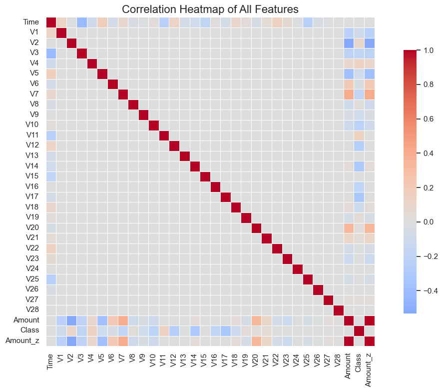

```python
# Compute correlation matrix
corr_matrix = df.corr()

# Plot heatmap
plt.figure(figsize=(12, 8))
sns.heatmap(corr_matrix, cmap='coolwarm', center=0, linewidths=0.5,
            annot=False, fmt='.2f', square=True, cbar_kws={'shrink': 0.8})
plt.title('Correlation Heatmap of All Features', fontsize=16)
plt.tight_layout()
plt.show()
```

6.2 Correlation of All Features with Class

```python
# Correlation of all features with target
class_corr = corr_matrix['Class'].drop('Class').sort_values(key=abs, ascending=False)

# Display top 10 most correlated features
top_corr_features = class_corr.head(10)
top_corr_features.to_frame(name='Correlation with Class')
```

|  | Correlation with Class |
| --- | --- |
| V17 | -0.326481 |
| V14 | -0.302544 |
| V12 | -0.260593 |
| V10 | -0.216883 |
| V16 | -0.196539 |
| V3 | -0.192961 |
| V7 | -0.187257 |
| V11 | 0.154876 |
| V4 | 0.133447 |
| V18 | -0.111485 |

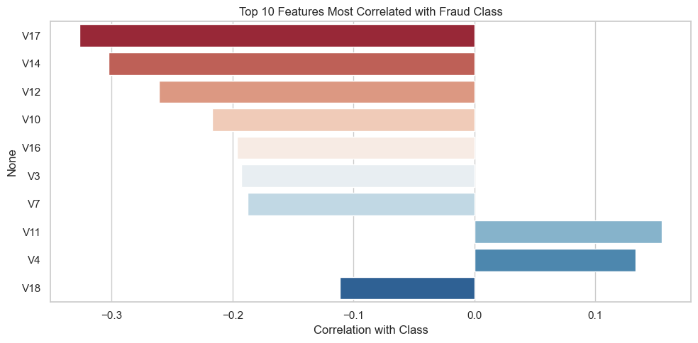

```python
# Bar Plot of Feature Correlations with Class
plt.figure(figsize=(10,5))
sns.barplot(x=top_corr_features.values, y=top_corr_features.index, palette='RdBu')
plt.title("Top 10 Features Most Correlated with Fraud Class")
plt.xlabel("Correlation with Class")
plt.tight_layout()
plt.show()
```

6.3 Pair Plots (Fraud vs. Non-Fraud)

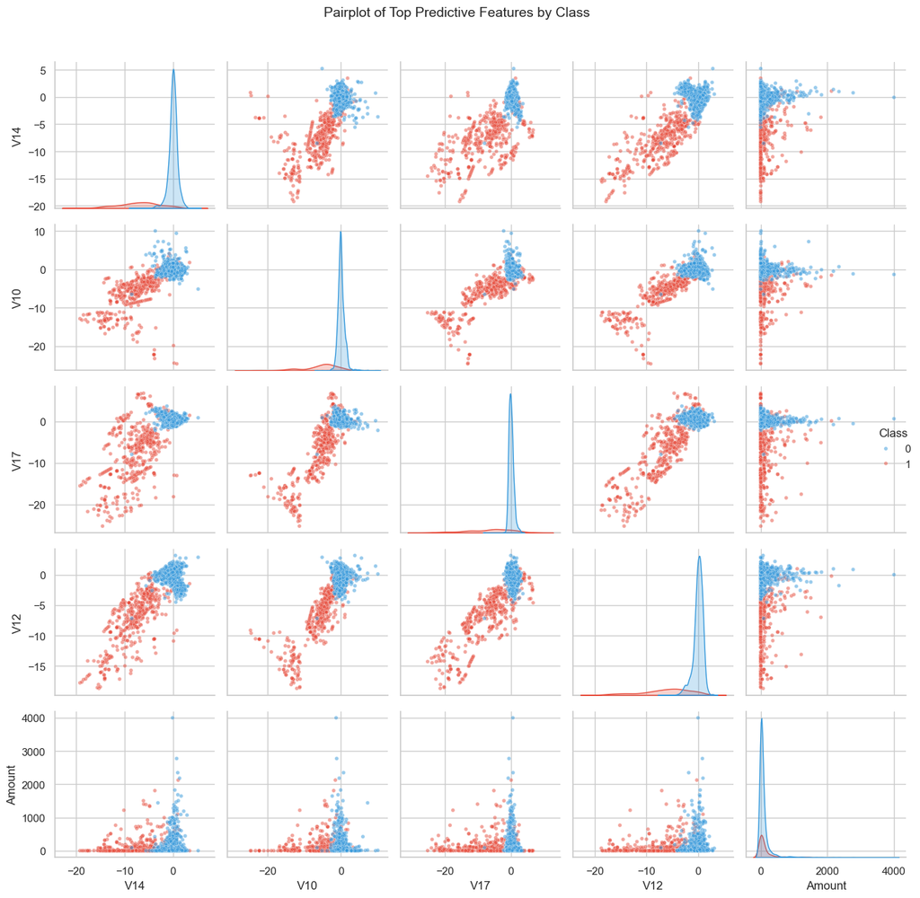

```python
from sklearn.utils import resample

# Sample equal number of fraud and non-fraud transactions for visualization
fraud_df = df[df['Class'] == 1]
nonfraud_sample = df[df['Class'] == 0].sample(n=len(fraud_df)*4, random_state=42)

pair_df = pd.concat([fraud_df, nonfraud_sample])

# Only plot top correlated features
selected_features = ['V14', 'V10', 'V17', 'V12', 'Amount', 'Class']

sns.pairplot(pair_df[selected_features], hue='Class', palette=['#3498db', '#e74c3c'],
             plot_kws={'alpha':0.5, 's':15}, diag_kind='kde')
plt.suptitle('Pairplot of Top Predictive Features by Class', fontsize=14, y=1.02)
plt.tight_layout()
plt.show()
```

6.4 Time-Series Analysis of Fraud Patterns

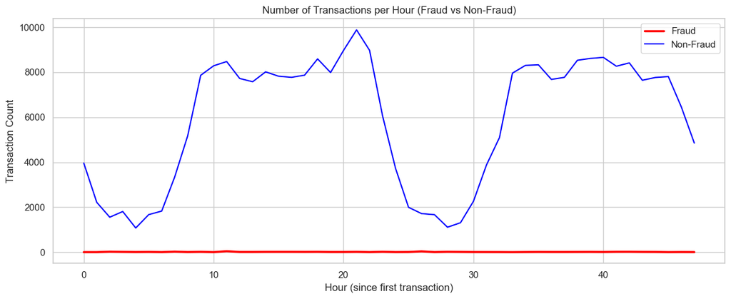

```python
# Bin time into hourly windows (or any custom interval)
df['Hour'] = (df['Time'] // 3600).astype(int)

# Fraud and non-fraud counts per hour
fraud_by_hour = df[df['Class'] == 1]['Hour'].value_counts().sort_index()
nonfraud_by_hour = df[df['Class'] == 0]['Hour'].value_counts().sort_index()

plt.figure(figsize=(12,5))
sns.lineplot(x=fraud_by_hour.index, y=fraud_by_hour.values, label='Fraud', color='red', linewidth=2.5)
sns.lineplot(x=nonfraud_by_hour.index, y=nonfraud_by_hour.values, label='Non-Fraud', color='blue', linewidth=1.5)
plt.title("Number of Transactions per Hour (Fraud vs Non-Fraud)")
plt.xlabel("Hour (since first transaction)")
plt.ylabel("Transaction Count")
plt.legend()
plt.tight_layout()
plt.show()
```